# Untitled

Andreas Gravers, Lars Nielsen, Jens Stoustrup

15/9/2019

# SDS 2019: M1 Assignment 2

Description This time you will work with Pokemon data. No data munging needed. Just old-school ML. Data You will find the dataset for this assignment under: https://github.com/SDS-AAU/M1-2019/raw/master/data/pokemon.csv

It contains data on 800 Pokemon from the 1st to the 6th generation.

```r
library(tidyverse)
library(ggforce)
library(caret)
library(yardstick)
library(knitr)
library(ggthemes)
library(ggridges)

set.seed(15092019)

poke <- read_csv("https://github.com/SDS-AAU/M1-2019/raw/master/data/pokemon.csv")
```

## 1. Unsupervised ML

### a. PCA analysis

Execute a PCA analysis on all numerical variables in the dataset. Hint: Don’t forget to scale them before. Use 4 components. What is the cumulative explained variance ratio?

```r
poke_scaled <- poke %>%
  select(HitPoints, Attack, Defense, SpecialAttack, SpecialDefense, Speed, Generation) %>%
  map_dfc(.f = scale)

PCA <- prcomp(poke_scaled, rank. = 4)
summary(PCA)
```

```
## Importance of first k=4 (out of 7) components:
##                           PC1    PC2    PC3    PC4
## Standard deviation     1.6479 1.0535 0.9932 0.8802
## Proportion of Variance 0.3879 0.1585 0.1409 0.1107
## Cumulative Proportion  0.3879 0.5465 0.6874 0.7981
```

```
## [1] "The cumulative explained variance ratio is 79.81%"
```

```r
loadings <- PCA$rotation %>%
  abs() %>%
  sweep(2, colSums(.), "/") %>%
  as.data.frame %>%
  rownames_to_column("name")

loadings[,-1] <- apply(loadings[,-1], MARGIN = 2, FUN = round, digits=2)

a <- loadings %>% dplyr::select(name, PC1) %>% arrange(desc(PC1))
b <- loadings %>% dplyr::select(name, PC2) %>% arrange(desc(PC2))
c <- loadings %>% dplyr::select(name, PC3) %>% arrange(desc(PC3))
d <- loadings %>% dplyr::select(name, PC4) %>% arrange(desc(PC4))

kable(cbind(a,b,c,d))
```

| name | PC1 | name | PC2 | name | PC3 | name | PC4 |
| --- | --- | --- | --- | --- | --- | --- | --- |
| Attack | 0.18 | Speed | 0.30 | Generation | 0.53 | Attack | 0.28 |
| SpecialAttack | 0.18 | Defense | 0.26 | Defense | 0.16 | SpecialDefense | 0.26 |
| SpecialDefense | 0.18 | Generation | 0.17 | SpecialDefense | 0.10 | HitPoints | 0.20 |
| HitPoints | 0.16 | SpecialAttack | 0.13 | Speed | 0.10 | SpecialAttack | 0.15 |
| Defense | 0.15 | SpecialDefense | 0.09 | SpecialAttack | 0.05 | Generation | 0.06 |
| Speed | 0.13 | HitPoints | 0.05 | HitPoints | 0.03 | Speed | 0.03 |
| Generation | 0.02 | Attack | 0.00 | Attack | 0.03 | Defense | 0.02 |

### b. Clustering

Perform a cluster analysis (either k-means or hierarchical clustering algorithm) on all numerical variables (scaled & before PCA). Apply the elbow method to determine a “pragmatic” number of clusters.

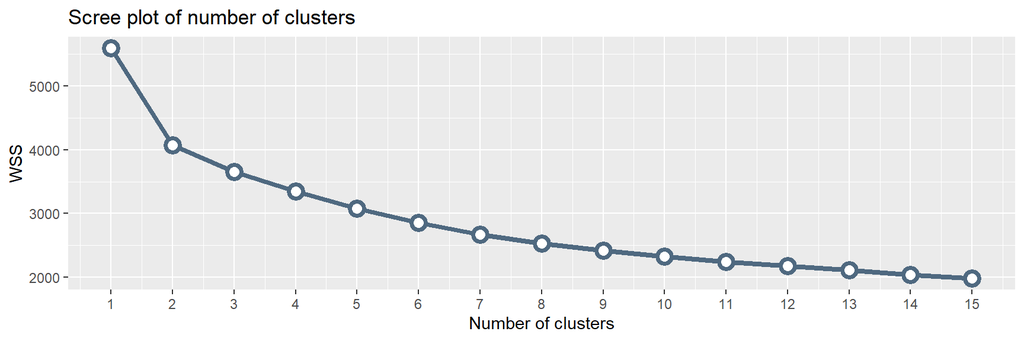

```r
wss <- 0
for (i in 1:15) {
  wss[i] <- kmeans(poke_scaled, centers = i, nstart=20)$tot.withinss
}

scree <- tibble(wss, N=1:15)

ggplot(scree, aes(N, wss)) +
  geom_line(size=1.5, color="#4f6980") +
  geom_point(size=3, shape=21, fill="white", color="#4f6980", stroke=2) +
  scale_x_continuous(breaks=c(1:15)) +
  labs(title="Scree plot of number of clusters", x="Number of clusters", y="WSS")
```

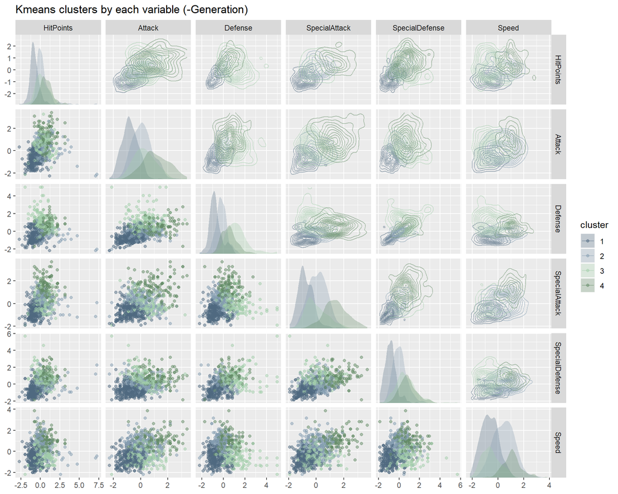

```r
km <- poke_scaled %>%
  kmeans(centers = 4, nstart = 20)

poke_scaled$cluster <- as.factor(km$cluster)

ex <- km$centers %>% as_tibble %>% mutate(N=1:4) %>% gather(variable, value, -N)

ggplot(poke_scaled, aes(x = .panel_x, y = .panel_y, colour = cluster, fill = cluster)) +
  geom_point(alpha = 0.5, position = 'auto') +
  geom_autodensity(alpha = 0.3, colour = NA, position = 'identity') +
  geom_density2d(alpha = 0.5) +
  scale_color_tableau(palette = "Miller Stone", type = "regular") +
  scale_fill_tableau(palette = "Miller Stone", type = "regular") +
  facet_matrix(vars(-cluster, -Generation), layer.diag = 2, layer.upper = 3) +
  labs(title="Kmeans clusters by each variable (-Generation)")
```

### c. Visualization

Visualize the first 2 principal components and color the datapoints by cluster.

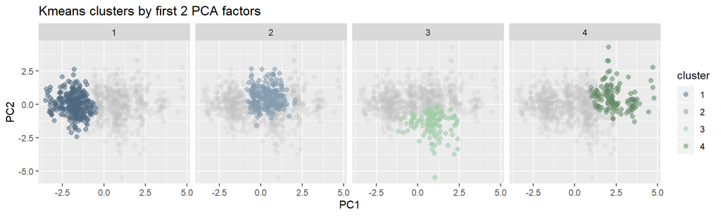

```r
df <- tibble(PC1 = PCA$x[,1], PC2 = PCA$x[,2], cluster=as.factor(km$cluster))


ggplot(df, aes(PC1, PC2, col = cluster)) +
  geom_point(data=df %>% select(-cluster), aes(PC1, PC2), inherit.aes = F, color="grey75", alpha=0.2, size=2) +
  geom_point(alpha=0.5, size=2) +
  scale_color_tableau(palette = "Miller Stone", type = "regular") +
  facet_wrap(~cluster, nrow=1) +
  labs(title="Kmeans clusters by first 2 PCA factors")
```

### d. Inspection

Inspect the distribution of the variable “Type1” across clusters. Does the algorithm separate the different types of pokemon?

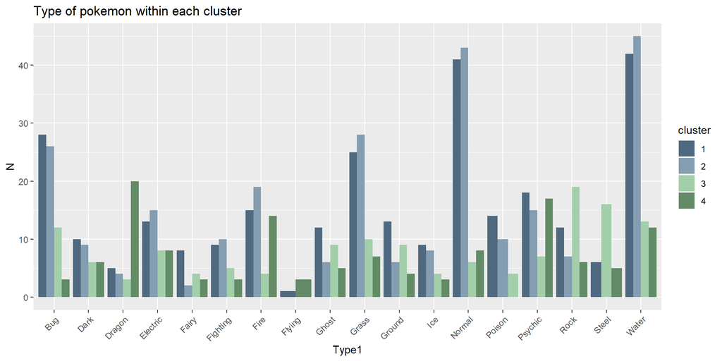

```r
poke_scaled %>% mutate(Type1 = poke$Type1,
                       cluster = as.factor(km$cluster)) %>%
  group_by(Type1, cluster) %>%
  summarize(N=n()) %>%
  ggplot(aes(Type1, N, fill=cluster)) + geom_col(position = "dodge") +
  scale_fill_tableau(palette = "Miller Stone", type = "regular") +
  theme(axis.text.x = element_text(angle = 45, hjust = 1)) +
  labs(title="Type of pokemon within each cluster")
```

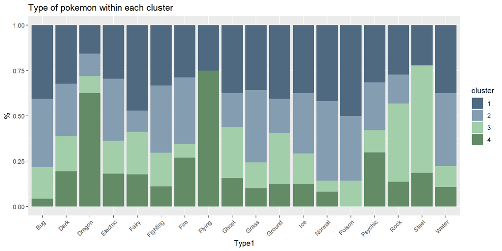

```r
poke_scaled %>% mutate(Type1 = poke$Type1,
                       cluster = as.factor(km$cluster)) %>%
  group_by(Type1, cluster) %>%
  summarize(N=n()) %>%
  ggplot(aes(Type1, N, fill=cluster)) + geom_col(position = "fill") +
  scale_fill_tableau(palette = "Miller Stone", type = "regular") +
  theme(axis.text.x = element_text(angle = 45, hjust = 1)) +
  labs(title="Type of pokemon within each cluster", y="%")
```

## 2. Supervised ML

Your task will be to predict the variable “legendary”, indicating if the pokemon is a legendary one or not.

### a. Preprocessing

Perform necessary ML preprocessing of your data if deemed necessary.

```r
poke_ml <- poke %>%
  select(HitPoints, Attack, Defense, SpecialAttack, SpecialDefense, Speed, Generation, Legendary) %>%
  map_dfc(.f = scale) %>%
  mutate(Legendary = as.factor(poke$Legendary))

head(poke_ml)
```

```
## # A tibble: 6 x 8
##   HitPoints[,1] Attack[,1] Defense[,1] SpecialAttack[,~ SpecialDefense[~
##           <dbl>      <dbl>       <dbl>            <dbl>            <dbl>
## 1        -0.950    -0.924       -0.797           -0.239           -0.248
## 2        -0.363    -0.524       -0.348            0.219            0.291
## 3         0.421     0.0924       0.294            0.831            1.01
## 4         0.421     0.647        1.58             1.50             1.73
## 5        -1.19     -0.832       -0.989           -0.392           -0.787
## 6        -0.441    -0.462       -0.508            0.219           -0.248
## # ... with 3 more variables: Speed[,1] <dbl>, Generation[,1] <dbl>,
## #   Legendary <fct>
```

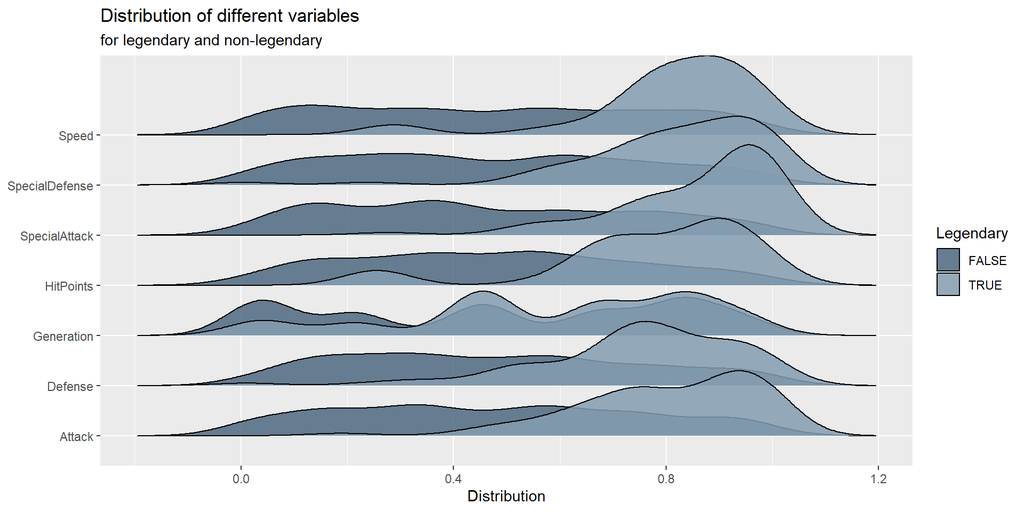

```r
poke_ml %>%
  gather(variable, value, -Legendary) %>%
  ggplot(aes(y = as.factor(variable),
             fill =  Legendary,
             x = percent_rank(value)) ) +
  scale_fill_tableau(palette = "Miller Stone", type = "regular") +
  geom_density_ridges(alpha = 0.85) +
  labs(title = "Distribution of different variables", subtitle = "for legendary and non-legendary",
       fill="Legendary", y="Feature", x="Distribution") + theme(axis.title.y = element_blank())
```

### b. Split

Split the data in a training (75%) and test (25%) dataset.

```r
index    <- createDataPartition(poke_ml$Legendary, p = 0.75, list = FALSE)
training <- poke_ml[index,]
test     <- poke_ml[-index,]

dim(training)
```

```
## [1] 601   8
```

```r
dim(test)
```

```
## [1] 199   8
```

### c. Cross-validation

Define a n-fold cross-validation workflow for your model testing.

```r
cv <- trainControl(method = "cv", number = 5)
```

### d. Models

Fit three separate models on your training data, where you predict the “legendary” variable. Use a 1. Logistic regression, 2. Decision tree, and 3. another algorithm of choice to do so.

```r
fit_log <- train(Legendary ~ .,
                 data      = training,
                 trControl = cv,
                 tuneGrid  = expand.grid(alpha  = 0.5,
                                         lambda = 0),
                 method    = "glmnet",
                 family    = "binomial",
                 metric    = 'Accuracy')

fit_glm <- train(Legendary ~ .,
                 data      = training,
                 trControl = cv,
                 tuneGrid  = expand.grid(alpha  = seq(0, 1, by = 0.1),
                                         lambda = 10^seq(1, -4, by = -0.2)),
                 method    = "glmnet",
                 family    = "binomial",
                 metric    = 'Accuracy')


fit_raf <- train(Legendary ~ .,
                 data      = training,
                 trControl = cv,
                 tuneGrid  = expand.grid(.mtry = (1:7)),
                 method    = 'rf',
                 metric    = 'Accuracy')

fit_svm <- train(Legendary ~ .,
                 data      = training,
                 trControl = cv,
                 tuneGrid  = expand.grid(C = 10^seq(1, -1, by = -0.02)),
                 method    = 'svmLinear',
                 metric    = 'Accuracy')

fit_lda <- train(Legendary ~ .,
                 data      = training,
                 trControl = cv,
                 method    = "lda",
                 metric    = 'Accuracy')
```

### e. Prediction

Use the fitted models to predict the “legendary” variable in your test data.

```r
pred_log <- predict(fit_log,  test)
conf_log <- table(pred_log, test$Legendary)

pred_glm <- predict(fit_glm,  test)
conf_glm <- table(pred_glm, test$Legendary)

pred_svm <- predict(fit_svm,  test)
conf_svm <- table(pred_svm, test$Legendary)

pred_raf <- predict(fit_raf,  test)
conf_raf <- table(pred_raf, test$Legendary)

pred_lda <- predict(fit_lda,  test)
conf_lda <- table(pred_lda, test$Legendary)


#kable(list(data.frame("Model"="Logistic"),conf_log, data.frame("Model"="lasticNet"), conf_glm, conf_svm, conf_raf, conf_lda))

log <- rbind(spec(conf_log), precision(conf_log), accuracy(conf_log))
raf <- rbind(spec(conf_raf), precision(conf_raf), accuracy(conf_raf))
glm <- rbind(spec(conf_glm), precision(conf_glm), accuracy(conf_glm))
svm <- rbind(spec(conf_svm), precision(conf_svm), accuracy(conf_svm))
lda <- rbind(spec(conf_lda), precision(conf_lda), accuracy(conf_lda))

#kable(tibble("M"           = c("True Positive", "Type I", "Type II", "False Negative"),
#                 "Elastic Net" = c(conf_glm),
#                 "Logistic Regression"= c(conf_log),
#                 "Support Vector Machines" = c(conf_svm),
#                 "Random Forrest" = c(conf_raf),
#                 "Linear Diskriminant Analysis" = c(conf_lda)), caption = "Confision matrices tabel")

#kable(glm, caption = "Glmnet")
#kable(raf, caption = "Random Forrest")
#kable(svm, caption = "Support Vector Machine")
```

### f. Evaluation

Evaluate the performance of these 3 models by comparing the predicted and the true values of “legendary” in the test data. To do so, also create a confusion matrix.

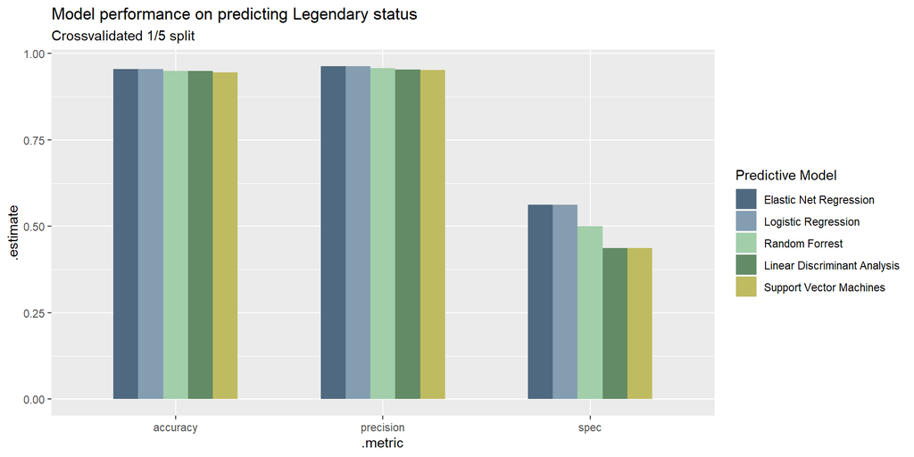

```r
log$model <- "Logistic Regression"
raf$model <- "Random Forrest"
glm$model <- "Elastic Net Regression"
svm$model <- "Support Vector Machines"
lda$model <- "Linear Discriminant Analysis"


df <- rbind(log, raf, glm, svm, lda)

ggplot(df, aes(.metric, .estimate, fill = reorder(model, desc(.estimate)))) +
  geom_col(position="dodge", width = 0.6) +
  scale_fill_tableau(palette = "Miller Stone", type = "regular") +
  labs(title="Model performance on predicting Legendary status", subtitle="Crossvalidated 1/5 split", fill="Predictive Model")
```

Submission 18. September 12:00. Peergrade.io (link + submission details will be sent out on Monday)

Please submit a PDF version of your notebook with a link to the corresponding colab notebook included. Please make sure(eg. own test in “anonymous” setting in your browser) that others can acess it.